# In-Class Session 5: Causality, DAGs, and Experiment Design

Econometrics I

This notebook reproduces the power calculations and the collider simulation from Lecture 5, and leaves you three short problems.

# Reproduce: power and sample size for an A/B test

From the lecture: baseline conversion 2%, and we want to detect a lift to 2.2% (a 10% relative lift) at $\alpha = 0.05$ with 80% power.

```r
power.prop.test(p1 = 0.02, p2 = 0.022, sig.level = 0.05, power = 0.80)
```

```
##
##      Two-sample comparison of proportions power calculation
##
##               n = 80681.38
##              p1 = 0.02
##              p2 = 0.022
##       sig.level = 0.05
##           power = 0.8
##     alternative = two.sided
##
## NOTE: n is number in *each* group
```

The required $n$ *per arm* (the slide’s formula gives 80,679; `power.prop.test()` uses the pooled variance under $H_0$, so it lands slightly higher). Now the sample-size/lift curve:

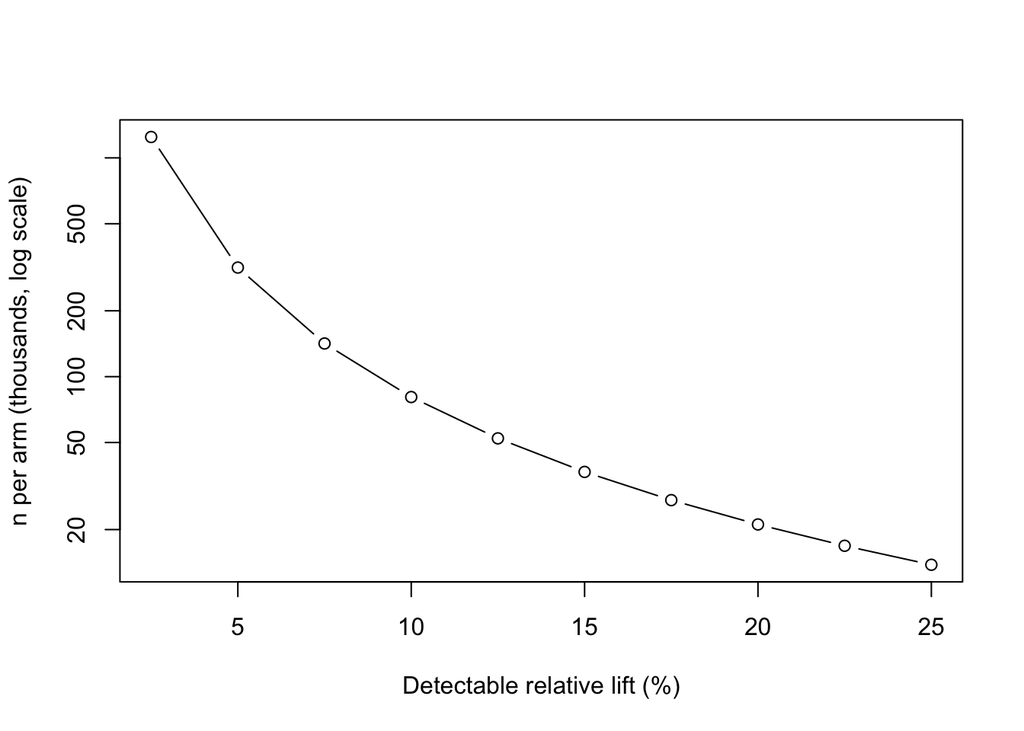

```r
lifts <- seq(0.0005, 0.005, by = 0.0005)
n_req <- sapply(lifts, function(d)
  power.prop.test(p1 = 0.02, p2 = 0.02 + d, sig.level = 0.05, power = 0.80)$n)
plot(100 * lifts / 0.02, n_req / 1000, type = "b", log = "y",
     xlab = "Detectable relative lift (%)", ylab = "n per arm (thousands, log scale)")
```

Small lifts are *brutally* expensive to detect — this is the Lewis–Rao point about advertising experiments.

# Reproduce: randomization inference in a few lines

A small experiment with a skewed outcome — exactly where the t-approximation is shakiest. 40 sellers, half treated, revenue is lognormal, true effect is a 30% lift:

```r
n <- 40
d <- sample(rep(0:1, n / 2))
y <- exp(rnorm(n, mean = 3, sd = 1)) * (1 + 0.3 * d)

observed <- mean(y[d == 1]) - mean(y[d == 0])
perm <- replicate(10000, {
  d_star <- sample(d)               # reshuffle labels, same # treated
  mean(y[d_star == 1]) - mean(y[d_star == 0])
})
c(observed = observed, p_value = mean(abs(perm) >= abs(observed)),
  t_test_p = t.test(y ~ d)$p.value)
```

```
##  observed   p_value  t_test_p
## 4.8027965 0.7583000 0.7291778
```

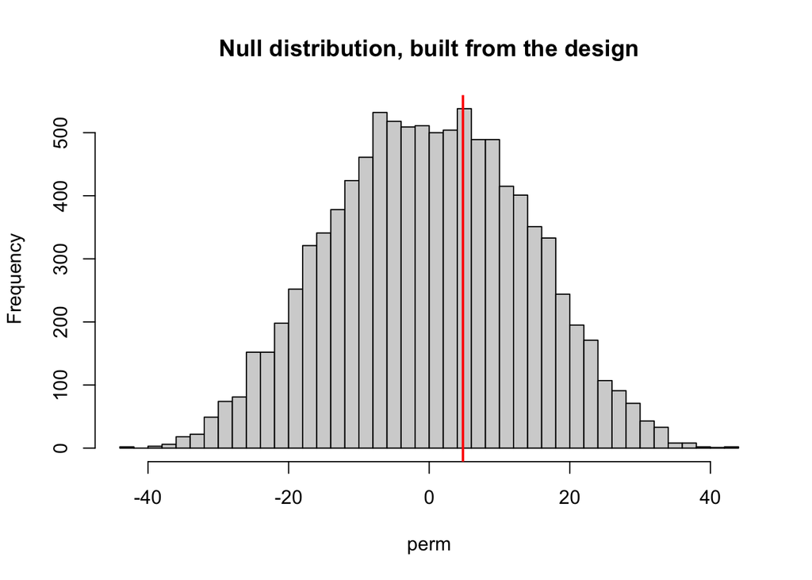

```r
hist(perm, breaks = 50, main = "Null distribution, built from the design")
abline(v = observed, col = "red", lwd = 2)
```

The histogram *is* the null distribution — no CLT required. Try re-running the chunk a few times: with n = 40 and lognormal outcomes, the permutation and t-test p-values usually agree roughly, but the permutation one needs no approximation to defend.

# Reproduce: the collider from the DAG lecture

Talent and luck are independent. Funding requires enough of either:

```r
n      <- 100000
talent <- rnorm(n)
luck   <- rnorm(n)
funded <- (talent + luck > 1.5)   # top ~14% get funded

cor(talent, luck)            # population: ~0
```

```
## [1] -0.0003224478
```

```r
cor(talent[funded], luck[funded])   # among the funded: strongly negative!
```

```
## [1] -0.6687855
```

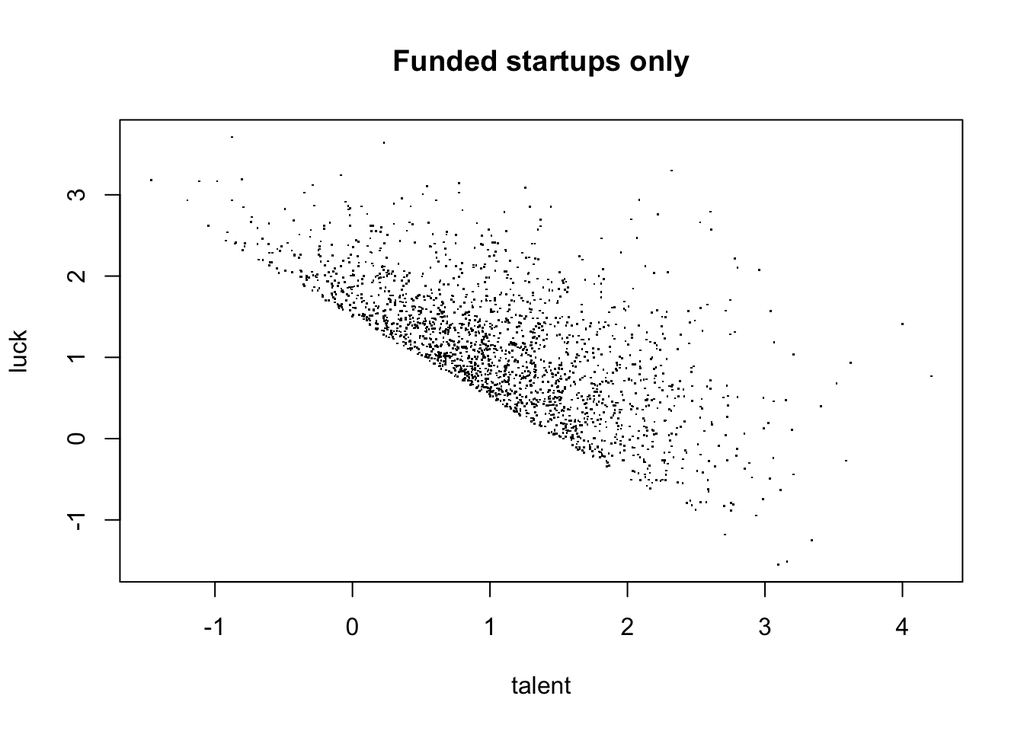

```r
plot(talent[funded][1:2000], luck[funded][1:2000], pch = ".",
     xlab = "talent", ylab = "luck", main = "Funded startups only")
```

Nobody made talent and luck trade off — *conditioning on the collider did*.

# Reproduce: interference in a marketplace

Buyers share a limited inventory. A coupon raises purchase propensity from 0.20 to 0.30. When supply binds, treated buyers take units control buyers would have bought, and the buyer-level A/B test overstates the effect of giving everyone the coupon.

```r
run_market <- function(treat, supply, p0 = 0.2, delta = 0.1) {
  want <- rbinom(length(treat), 1, p0 + delta * treat); sold <- integer(length(treat)); left <- supply
  for (i in sample(seq_along(treat))) if (want[i] == 1 && left > 0) { sold[i] <- 1L; left <- left - 1 }
  sold
}
B <- 200
for (ratio in c(0.75, 1, 2)) {
  supply <- round(ratio * 0.2 * B)
  est <- replicate(200, { tr <- rbinom(B, 1, 0.5); s <- run_market(tr, supply)
    c(naive = mean(s[tr == 1]) - mean(s[tr == 0]),
      global = mean(run_market(rep(1, B), supply)) - mean(run_market(rep(0, B), supply))) })
  cat(sprintf("supply/demand = %.2f:  buyer-level A/B %.3f   global effect %.3f\n", ratio, mean(est["naive", ]), mean(est["global", ])))
}
```

```
## supply/demand = 0.75:  buyer-level A/B 0.056   global effect 0.000
## supply/demand = 1.00:  buyer-level A/B 0.082   global effect 0.008
## supply/demand = 2.00:  buyer-level A/B 0.100   global effect 0.100
```

# In-class problem 1: the bad control, live

Simulate an advertising funnel: exposure to an ad is randomized, `exposed ~ Bernoulli(0.5)`. Visiting the site depends on exposure and interest: `visit = 1{0.5*exposed + interest + noise > 1}`, where `interest ~ N(0,1)`. Purchases depend on exposure (through brand awareness) and interest: `purchase = 0.1*exposed + 0.5*interest + error`.

**(a)** Regress `purchase` on `exposed` in the full sample. Since exposure is randomized, this is the causal effect. What do you get? **(b)** Now do what many dashboards do: run the same regression *only among visitors*. What happens to the estimated ad effect, and why? (Draw the DAG — which variable is the collider?)

```r
# your code here
```

# In-class problem 2: fix the marketplace experiment

Using `run_market` above with `ratio = 0.75`:

**(a)** Randomize the coupon at the *market* level instead (all buyers in a market treated or none), with 200 markets. Confirm the estimate is close to the global effect. Compare its standard error to the buyer-level test’s. **(b)** Vary the treated share within markets (10%, 50%, 90% of buyers) and record the mean sales of *control* buyers in each case. What pattern do you see, and what does it diagnose? **(c)** One sentence: what feature of a business would make you confident the buyer-level test is fine?

```r
# your code here
```

# In-class problem 3: design your own experiment

Your product team wants to test a new checkout flow. The current completion rate is 60%, and a change would only be worth engineering effort if it moves completion by at least 2 percentage points.

**(a)** How many users per arm do you need at $\alpha = 0.05$, power 0.8? **(b)** The team says “we only have 5,000 users a week, and we want an answer in two weeks.” What minimum detectable effect does that traffic actually buy you (solve `power.prop.test` for the detectable `p2` given n = 5000)? **(c)** Two sentences for the product manager: what do you recommend, and what is the risk of just running the underpowered test anyway?

```r
# your code here
```